# Body performance

#### Average silhouette for 3 clusters

|  | cluster | size | ave.sil.width |
| --- | --- | --- | --- |
| 1 | 1 | 2927 | 0.58 |
| 2 | 2 | 6760 | 0.60 |
| 3 | 3 | 3364 | 0.41 |

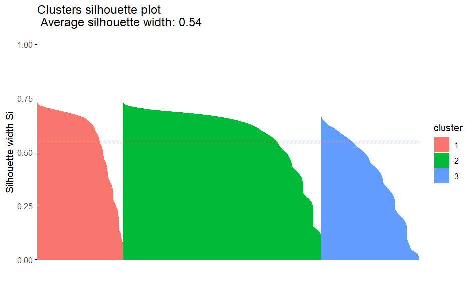

```r
library(cluster)
avg_sil <- silhouette(kmeans.result$cluster,dist(dataset))

fviz_silhouette(avg_sil)
```

#### Within cluster sum of squares by cluster:

```r
kmeans.result$tot.withinss
```

```
[1] 310351.6
```

#### BCubed precision and recall for k=3:

```r
cluster_assignments <- c(kmeans.result$cluster)
ground_truth_labels <- c(dataWithclass$class)

data <- data.frame(cluster = cluster_assignments, label = ground_truth_labels)

# Function to calculate BCubed precision and recall
calculate_bcubed_metrics <- function(data) {
  n <- nrow(data)
  precision_sum <- 0
  recall_sum <- 0

  for (i in 1:n) {
    cluster <- data$cluster[i]
    label <- data$label[i]

# Count the number of items from the same category within the same cluster
same_category_same_cluster <- sum(data$label[data$cluster == cluster] == label)

# Count the total number of items in the same cluster
total_same_cluster <- sum(data$cluster == cluster)

# Count the total number of items with the same category
total_same_category <- sum(data$label == label)

# Calculate precision and recall for the current item and add them to the sums
precision_sum <- precision_sum + same_category_same_cluster /total_same_cluster
recall_sum <- recall_sum + same_category_same_cluster / total_same_category
  }

  # Calculate average precision and recall
  precision <- precision_sum / n
  recall <- recall_sum / n

  return(list(precision = precision, recall = recall))
}

# Calculate BCubed precision and recall
metrics <- calculate_bcubed_metrics(data)

# Extract precision and recall from the metrics
precision <- metrics$precision
recall <- metrics$recall

# Print the results
cat("BCubed Precision:", precision, "\n")
```

```
BCubed Precision: 0.2516393
```

```r
cat("BCubed Recall:", recall, "\n")
```

```
BCubed Recall: 0.387276
```

-The average silhouette width of 0.54 suggests that there is a moderate separation between clusters, but it might not be as distinct as in the case of k=2.

-The lower WCSS (310351.6) compared to k=2 implies that the clusters are more compact, indicating that data points within each cluster are closer to each other. -These values indicate that about 25% of instances within the same cluster have the same ground truth label (Precision), and about 39% of instances with the same ground truth label are in the same cluster (Recall).

### Third cluster: 4-Means Cluster :

```r
#set a seed for random number generation  to make the results reproducible
set.seed(8953)
kmeans.result <- kmeans(dataset, 4)

# print the clusterng result
kmeans.result
```

```
K-means clustering with 4 clusters of sizes 2584, 3111, 2508, 4848

Cluster means:
       age    gender   height_cm   weight_kg body.fat_.   diastolic     systolic   gripForce
1 57.69776 0.5727554 -0.56792264 -0.28029622  0.4043106  0.18130122  0.354628131 -0.39897144
2 31.78367 0.7389907  0.29501288  0.27247972 -0.1655328  0.06079118  0.005814156  0.35619983
3 43.64035 0.6255981 -0.05428425  0.05189276  0.1134649  0.19309336  0.037745030 -0.01475634
4 23.67306 0.6169554  0.14147523 -0.05229910 -0.1679736 -0.23553669 -0.212275467 -0.00828931
  sit.and.bend.forward_cm sit.ups.counts broad.jump_cm
1             -0.06091930     -0.9270547    -0.7983590
2              0.01276129      0.3556528     0.3604086
3             -0.11340498     -0.2823826    -0.1201610
4              0.08294859      0.4119820     0.2564135

Clustering vector:
```

[output cut: 106 more lines]

#### Visualize 4 clusters:

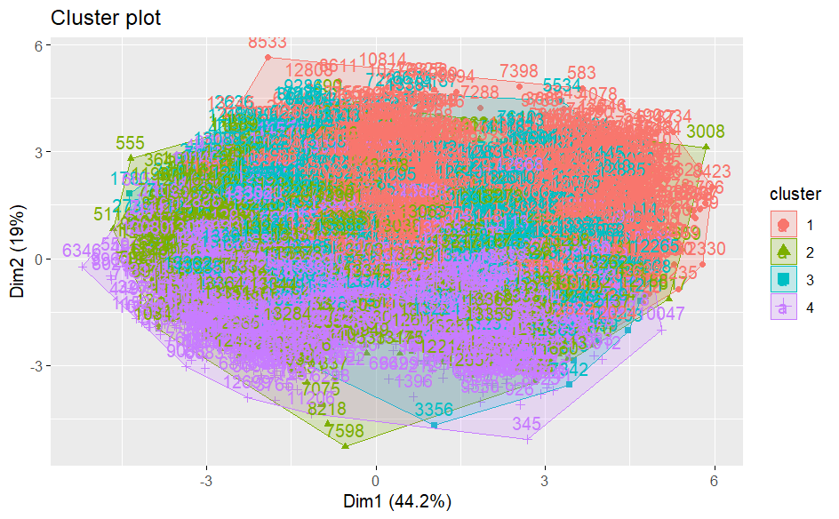

```r
# visualize clustering (2 clusters)
#install.packages("factoextra")
library(factoextra)
fviz_cluster(kmeans.result, data = dataset)
```

Based on the above results and cluster representation, First cluster contains 2584 objects with total sum of square 56577.82. Second cluster contains 3111 object with total sum of square 53341.05 . Third cluster contains 2508 objects with total sum of sequare 58639.75. Fourth cluster contains 4848 objects with total sum of sequare 61490.52, which is the highest total sum of squares. A higher sum of squares indicates a larger separation. Therefore, the objects in the fourth cluster are more separated. Cluster 2 has the lowest WSS value, followed by Cluster 1, Cluster 3, and Cluster 4. Therefore, Cluster 2 appears to be the most compact and well-defined cluster, while Cluster 4 shows a higher level of dispersion. Overall, the clustering algorithm has achieved a 90.4% separation, indicating a relatively high level of separation and distinctiveness between the four clusters.

#### Average silhouette for 4 clusters:

|  | cluster | size | ave.sil.width |
| --- | --- | --- | --- |
| 1 | 1 | 2584 | 0.55 |
| 2 | 2 | 3111 | 0.30 |
| 3 | 3 | 2508 | 0.37 |
| 4 | 4 | 4848 | 0.46 |

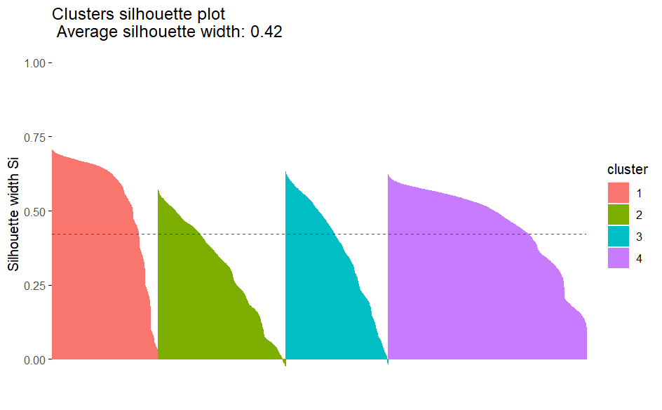

```r
library(cluster)
avg_sil <- silhouette(kmeans.result$cluster,dist(dataset))

fviz_silhouette(avg_sil)
```

#### Within cluster sum of squares by cluster:

```r
kmeans.result$tot.withinss
```

```
[1] 230049.1
```

#### BCubed precision and recall for k=4:

```r
cluster_assignments <- c(kmeans.result$cluster)
ground_truth_labels <- c(dataWithclass$class)

data <- data.frame(cluster = cluster_assignments, label = ground_truth_labels)

# Function to calculate BCubed precision and recall
calculate_bcubed_metrics <- function(data) {
  n <- nrow(data)
  precision_sum <- 0
  recall_sum <- 0

  for (i in 1:n) {
    cluster <- data$cluster[i]
    label <- data$label[i]

# Count the number of items from the same category within the same cluster
same_category_same_cluster <- sum(data$label[data$cluster == cluster] == label)

# Count the total number of items in the same cluster
total_same_cluster <- sum(data$cluster == cluster)

# Count the total number of items with the same category
total_same_category <- sum(data$label == label)

# Calculate precision and recall for the current item and add them to the sums
precision_sum <- precision_sum + same_category_same_cluster /total_same_cluster
recall_sum <- recall_sum + same_category_same_cluster / total_same_category
  }

  # Calculate average precision and recall
  precision <- precision_sum / n
  recall <- recall_sum / n

  return(list(precision = precision, recall = recall))
}

# Calculate BCubed precision and recall
metrics <- calculate_bcubed_metrics(data)

# Extract precision and recall from the metrics
precision <- metrics$precision
recall <- metrics$recall

# Print the results
cat("BCubed Precision:", precision, "\n")
```

```
BCubed Precision: 0.2522583
```

```r
cat("BCubed Recall:", recall, "\n")
```

```
BCubed Recall: 0.2729353
```

-The average silhouette width of 0.42 suggests a moderate level of separation between clusters, indicating that the clusters are distinguishable, but there may be some overlap. -The lower WCSS indicates that the clusters are relatively compact, with instances within each cluster being closer to each other.

-The BCubed metrics : A Precision of 0.25 means that about 25% of instances within the same cluster have the same ground truth label. A Recall of 0.27 means that about 27% of instances with the same ground truth label are in the same cluster.

## 6. Evaluation and Comparison:

### 6.1 Classification:

80% training 20% testing:

Table 12: 80/20 Comparison Classification algorithm

|  | GI | GI ratio | Gini Index |
| --- | --- | --- | --- |
| Accuracy | 57.48% | 57.37% | 57.37% |
| Sensitivity(Recall) | 43.56% | 43.32% | 43.32% |
| Specificity | 61.18% | 61.95% | 61.95% |
| Precision | 61.18% | 61.95% | 61.95% |

In this partitioning, GI exhibits a slightly higher accuracy, suggesting that it may be marginally more predictive than the other algorithms, albeit with a small difference.

75% training 25% testing:

Table 13: 75/25 Comparison Classification algorithm

|  | GI | GI ratio | Gini Index |
| --- | --- | --- | --- |
| Accuracy | 57.8% | 57.58% | 57.58% |
| Sensitivity(Recall) | 43.86% | 40.20% | 40.20% |
| Specificity | 60.97% | 52.47% | 52.47% |
| Precision | 60.97% | 61.81% | 61.81% |

in 75/25 GI stands out with slightly higher accuracy, sensitivity, and specificity compared to GI ratio and Gini Index. These metrics collectively suggest that GI performs slightly better in correctly classifying instances, especially in identifying positive and negative cases.

70% training 30% testing:

Table 14: 70/30 Comparison Classification algorithm

|  | GI | GI ratio | Gini Index |
| --- | --- | --- | --- |
| Accuracy | 57.6% | 57.86% | 57.86% |
| Sensitivity(Recall) | 43.88% | 41.42% | 41.42% |
| Specificity | 60.5% | 60.59% | 60.59% |
| Precision | 60.5% | 60.59% | 60.59% |

with a 70%-30% training-testing split, GI ratio slightly outperforms the other algorithms in terms of accuracy and specificity. However, GI maintains a higher sensitivity, suggesting better performance in identifying positive instances. The precision values are consistent across all algorithms. Overall, the choice of algorithm may depend on specific priorities, such as whether false positives or false negatives carry more significance in the given context.

### 6.2 Clustering:

Table 15: Comparison clusters

| No. of Clusters | k=2 (best) | k=3 | k=4 |
| --- | --- | --- | --- |
| Average Silhouette width for each cluter | cluter 1=0.56, clute r2=0.67 | clute r1=0.58 , clute r2=0.60 , clute r3=0.41 | clute r1=0.55 , clute r2=0.30 , clute r3=0.37 ,clute r4=0.46 |
| Average Silhouette width | 0.63 | 0.54 | 0.42 |
| Total within- cluster sum of square | 5 91064.6 | 3 10351.6 | 2 30049.1 |
| BCubed Precison | 0 . 2516112 | 0 . 2516393 | 0 . 2522583 |
| BCubed Recall | 0 . 5454527 | 0 .387276 | 0 . 2729353 |

Upon comparing the results of the clustering task using the k-means algorithm reveal that the most effective cluster configuration is achieved when k=2. This is supported by the higher average silhouette width for cluster 2 (0.67) compared to the other clusters in different configurations. It suggests that instances within cluster 2 are closely grouped and well-separated from instances in other clusters, indicating a higher level of cohesion and separation. Furthermore, the overall average silhouette width for k=2 (0.63) surpasses the average values for k=3 (0.54) and k=4 (0.42), indicating better overall clustering performance.

## 7. Finding:

Based on Comparison Criteria, it appears that the clustering algorithm has achieved a relatively high average silhouette width of 63%, indicating that the clusters generated are well-separated and the instances within each cluster are similar to one another. This suggests that the clustering algorithm has successfully identified distinct groups or patterns in our body performance dataset. While the Classification accuracy achieved is 57.86%. This means that the classification model correctly predicted the class labels for 57.86% of the instances in the test set. Therefor, Clustering can be more suitable.

However, Considering the project’s goal and the problem at hand, the clustering task encountered challenges primarily due to the presence of overlapping clusters. While the clustering task facilitated the understanding of similarities among body performance data points, it did not directly contribute to problem-solving or goal attainment. while the classification task emerged as the more advantageous approach for analysis. By assigning class labels to the data, the classification task enabled the identification of influential factors significantly impacting body scores. (The decision tree algorithm provided valuable insights into these factors), shedding light on their importance and relationships. However, the accurcy does not provide quality of the classification model.

In summary, considering the similar percentage result achieved by both classification and clustering approaches, we made the decision to choose classification due to its direct suitability to our specific problem and its effective ability to accurately classify the data.<sup>[[6]](https://www.kaggle.com/code/shivanirana63/guide-to-complete-statistical-analysis)</sup>

## 8. References:

> [1] [“Body performance Data,” Kaggle, Jun. 29, 2022.](https://www.kaggle.com/datasets/kukuroo3/body-performance-data)

> [2].[Codeguyas, “Body Performance Data EDA,” Kaggle, Dec. 19, 2021.](https://www.kaggle.com/code/codeguyas101/body-performance-data-eda)

> [3]. [“discretize function - RDocumentation.”](https://www.rdocumentation.org/packages/arules/versions/1.6-4/topics/discretize)

> [4].[“RPubs - Classification and Regression Trees (CART) in R.”](https://rpubs.com/camguild/803096)

> [5]. [“RPubs - Cluster Analysis in R.”](https://rpubs.com/odenipinedo/cluster-analysis-in-R)

> [6].[Shivanirana, “📌🧐Guide to Complete Statistical Analysis📊✅,” Kaggle, Mar. 11, 2022.](https://www.kaggle.com/code/shivanirana63/guide-to-complete-statistical-analysis)

> [overall].[Body performance note book](https://rpubs.com/TeraPutera/LBB-CM-2)